# Breast Cancer Prediction

By Raphaël Roux, Adrien Servas, Romain Requena, Léonard Seidlitz

## Stage 1

```python
import pandas as pd
import numpy as np
import seaborn as sns
import matplotlib.pyplot as plt

from sklearn.decomposition import PCA
from sklearn.preprocessing import StandardScaler

from sklearn.model_selection import train_test_split
from sklearn.linear_model import LogisticRegression
from sklearn.svm import SVC
from sklearn.ensemble import RandomForestClassifier
from sklearn.neighbors import KNeighborsClassifier
from sklearn.metrics import accuracy_score, confusion_matrix, classification_report
from sklearn.model_selection import cross_val_score, StratifiedKFold
```

```python
df = pd.read_csv('Cancer_data.csv')
```

### Data Analysis

#### Infos and Statistics

```python
df.info()
```

```
<class 'pandas.core.frame.DataFrame'>
RangeIndex: 569 entries, 0 to 568
Data columns (total 33 columns):
 #   Column                   Non-Null Count  Dtype
---  ------                   --------------  -----
 0   id                       569 non-null    int64
 1   diagnosis                569 non-null    object
 2   radius_mean              569 non-null    float64
 3   texture_mean             569 non-null    float64
 4   perimeter_mean           569 non-null    float64
 5   area_mean                569 non-null    float64
 6   smoothness_mean          569 non-null    float64
 7   compactness_mean         569 non-null    float64
 8   concavity_mean           569 non-null    float64
 9   concave points_mean      569 non-null    float64
```

[output cut: 25 more lines]

```python
df.describe().T
```

|  | count | mean | std | min | 25% | 50% | 75% | max |
| --- | --- | --- | --- | --- | --- | --- | --- | --- |
| id | 569.0 | 3.037183e+07 | 1.250206e+08 | 8670.000000 | 869218.000000 | 906024.000000 | 8.813129e+06 | 9.113205e+08 |
| radius_mean | 569.0 | 1.412729e+01 | 3.524049e+00 | 6.981000 | 11.700000 | 13.370000 | 1.578000e+01 | 2.811000e+01 |
| texture_mean | 569.0 | 1.928965e+01 | 4.301036e+00 | 9.710000 | 16.170000 | 18.840000 | 2.180000e+01 | 3.928000e+01 |
| perimeter_mean | 569.0 | 9.196903e+01 | 2.429898e+01 | 43.790000 | 75.170000 | 86.240000 | 1.041000e+02 | 1.885000e+02 |
| area_mean | 569.0 | 6.548891e+02 | 3.519141e+02 | 143.500000 | 420.300000 | 551.100000 | 7.827000e+02 | 2.501000e+03 |
| smoothness_mean | 569.0 | 9.636028e-02 | 1.406413e-02 | 0.052630 | 0.086370 | 0.095870 | 1.053000e-01 | 1.634000e-01 |
| compactness_mean | 569.0 | 1.043410e-01 | 5.281276e-02 | 0.019380 | 0.064920 | 0.092630 | 1.304000e-01 | 3.454000e-01 |
| concavity_mean | 569.0 | 8.879932e-02 | 7.971981e-02 | 0.000000 | 0.029560 | 0.061540 | 1.307000e-01 | 4.268000e-01 |
| concave points_mean | 569.0 | 4.891915e-02 | 3.880284e-02 | 0.000000 | 0.020310 | 0.033500 | 7.400000e-02 | 2.012000e-01 |
| symmetry_mean | 569.0 | 1.811619e-01 | 2.741428e-02 | 0.106000 | 0.161900 | 0.179200 | 1.957000e-01 | 3.040000e-01 |
| fractal_dimension_mean | 569.0 | 6.279761e-02 | 7.060363e-03 | 0.049960 | 0.057700 | 0.061540 | 6.612000e-02 | 9.744000e-02 |
| radius_se | 569.0 | 4.051721e-01 | 2.773127e-01 | 0.111500 | 0.232400 | 0.324200 | 4.789000e-01 | 2.873000e+00 |
| texture_se | 569.0 | 1.216853e+00 | 5.516484e-01 | 0.360200 | 0.833900 | 1.108000 | 1.474000e+00 | 4.885000e+00 |
| perimeter_se | 569.0 | 2.866059e+00 | 2.021855e+00 | 0.757000 | 1.606000 | 2.287000 | 3.357000e+00 | 2.198000e+01 |
| area_se | 569.0 | 4.033708e+01 | 4.549101e+01 | 6.802000 | 17.850000 | 24.530000 | 4.519000e+01 | 5.422000e+02 |
| smoothness_se | 569.0 | 7.040979e-03 | 3.002518e-03 | 0.001713 | 0.005169 | 0.006380 | 8.146000e-03 | 3.113000e-02 |
| compactness_se | 569.0 | 2.547814e-02 | 1.790818e-02 | 0.002252 | 0.013080 | 0.020450 | 3.245000e-02 | 1.354000e-01 |
| concavity_se | 569.0 | 3.189372e-02 | 3.018606e-02 | 0.000000 | 0.015090 | 0.025890 | 4.205000e-02 | 3.960000e-01 |
| concave points_se | 569.0 | 1.179614e-02 | 6.170285e-03 | 0.000000 | 0.007638 | 0.010930 | 1.471000e-02 | 5.279000e-02 |
| symmetry_se | 569.0 | 2.054230e-02 | 8.266372e-03 | 0.007882 | 0.015160 | 0.018730 | 2.348000e-02 | 7.895000e-02 |
| fractal_dimension_se | 569.0 | 3.794904e-03 | 2.646071e-03 | 0.000895 | 0.002248 | 0.003187 | 4.558000e-03 | 2.984000e-02 |
| radius_worst | 569.0 | 1.626919e+01 | 4.833242e+00 | 7.930000 | 13.010000 | 14.970000 | 1.879000e+01 | 3.604000e+01 |
| texture_worst | 569.0 | 2.567722e+01 | 6.146258e+00 | 12.020000 | 21.080000 | 25.410000 | 2.972000e+01 | 4.954000e+01 |
| perimeter_worst | 569.0 | 1.072612e+02 | 3.360254e+01 | 50.410000 | 84.110000 | 97.660000 | 1.254000e+02 | 2.512000e+02 |
| area_worst | 569.0 | 8.805831e+02 | 5.693570e+02 | 185.200000 | 515.300000 | 686.500000 | 1.084000e+03 | 4.254000e+03 |
| smoothness_worst | 569.0 | 1.323686e-01 | 2.283243e-02 | 0.071170 | 0.116600 | 0.131300 | 1.460000e-01 | 2.226000e-01 |
| compactness_worst | 569.0 | 2.542650e-01 | 1.573365e-01 | 0.027290 | 0.147200 | 0.211900 | 3.391000e-01 | 1.058000e+00 |
| concavity_worst | 569.0 | 2.721885e-01 | 2.086243e-01 | 0.000000 | 0.114500 | 0.226700 | 3.829000e-01 | 1.252000e+00 |
| concave points_worst | 569.0 | 1.146062e-01 | 6.573234e-02 | 0.000000 | 0.064930 | 0.099930 | 1.614000e-01 | 2.910000e-01 |
| symmetry_worst | 569.0 | 2.900756e-01 | 6.186747e-02 | 0.156500 | 0.250400 | 0.282200 | 3.179000e-01 | 6.638000e-01 |
| fractal_dimension_worst | 569.0 | 8.394582e-02 | 1.806127e-02 | 0.055040 | 0.071460 | 0.080040 | 9.208000e-02 | 2.075000e-01 |
| Unnamed: 32 | 0.0 | NaN | NaN | NaN | NaN | NaN | NaN | NaN |

```python
df.isnull().sum()
```

```
id                           0
diagnosis                    0
radius_mean                  0
texture_mean                 0
perimeter_mean               0
area_mean                    0
smoothness_mean              0
compactness_mean             0
concavity_mean               0
concave points_mean          0
symmetry_mean                0
fractal_dimension_mean       0
radius_se                    0
texture_se                   0
perimeter_se                 0
area_se                      0
smoothness_se                0
compactness_se               0
concavity_se                 0
concave points_se            0
symmetry_se                  0
fractal_dimension_se         0
radius_worst                 0
texture_worst                0
perimeter_worst              0
area_worst                   0
smoothness_worst             0
compactness_worst            0
concavity_worst              0
concave points_worst         0
symmetry_worst               0
fractal_dimension_worst      0
Unnamed: 32                569
dtype: int64
```

```python
df.head()
```

|  | id | diagnosis | radius_mean | texture_mean | perimeter_mean | area_mean | smoothness_mean | compactness_mean | concavity_mean | concave points_mean | ... | texture_worst | perimeter_worst | area_worst | smoothness_worst | compactness_worst | concavity_worst | concave points_worst | symmetry_worst | fractal_dimension_worst | Unnamed: 32 |
| --- | --- | --- | --- | --- | --- | --- | --- | --- | --- | --- | --- | --- | --- | --- | --- | --- | --- | --- | --- | --- | --- |
| 0 | 842302 | M | 17.99 | 10.38 | 122.80 | 1001.0 | 0.11840 | 0.27760 | 0.3001 | 0.14710 | ... | 17.33 | 184.60 | 2019.0 | 0.1622 | 0.6656 | 0.7119 | 0.2654 | 0.4601 | 0.11890 | NaN |
| 1 | 842517 | M | 20.57 | 17.77 | 132.90 | 1326.0 | 0.08474 | 0.07864 | 0.0869 | 0.07017 | ... | 23.41 | 158.80 | 1956.0 | 0.1238 | 0.1866 | 0.2416 | 0.1860 | 0.2750 | 0.08902 | NaN |
| 2 | 84300903 | M | 19.69 | 21.25 | 130.00 | 1203.0 | 0.10960 | 0.15990 | 0.1974 | 0.12790 | ... | 25.53 | 152.50 | 1709.0 | 0.1444 | 0.4245 | 0.4504 | 0.2430 | 0.3613 | 0.08758 | NaN |
| 3 | 84348301 | M | 11.42 | 20.38 | 77.58 | 386.1 | 0.14250 | 0.28390 | 0.2414 | 0.10520 | ... | 26.50 | 98.87 | 567.7 | 0.2098 | 0.8663 | 0.6869 | 0.2575 | 0.6638 | 0.17300 | NaN |
| 4 | 84358402 | M | 20.29 | 14.34 | 135.10 | 1297.0 | 0.10030 | 0.13280 | 0.1980 | 0.10430 | ... | 16.67 | 152.20 | 1575.0 | 0.1374 | 0.2050 | 0.4000 | 0.1625 | 0.2364 | 0.07678 | NaN |

5 rows × 33 columns

##### Cleaning and Mapping

Last column is null and useless, we are droping it. We don't need id either for prediction.

```python
df = df.drop(columns=['Unnamed: 32', 'id'], axis=1)
```

```python
print(df['diagnosis'].value_counts(normalize=True))
```

```
diagnosis
B    0.627417
M    0.372583
Name: proportion, dtype: float64
```

Mapping of the column we will predict : Malign (M) = 1, Begnign (B) = 0

```python
df['diagnosis'] = df['diagnosis'].map({'M': 1, 'B': 0})
```

```python
df.head()
```

|  | diagnosis | radius_mean | texture_mean | perimeter_mean | area_mean | smoothness_mean | compactness_mean | concavity_mean | concave points_mean | symmetry_mean | ... | radius_worst | texture_worst | perimeter_worst | area_worst | smoothness_worst | compactness_worst | concavity_worst | concave points_worst | symmetry_worst | fractal_dimension_worst |
| --- | --- | --- | --- | --- | --- | --- | --- | --- | --- | --- | --- | --- | --- | --- | --- | --- | --- | --- | --- | --- | --- |
| 0 | 1 | 17.99 | 10.38 | 122.80 | 1001.0 | 0.11840 | 0.27760 | 0.3001 | 0.14710 | 0.2419 | ... | 25.38 | 17.33 | 184.60 | 2019.0 | 0.1622 | 0.6656 | 0.7119 | 0.2654 | 0.4601 | 0.11890 |
| 1 | 1 | 20.57 | 17.77 | 132.90 | 1326.0 | 0.08474 | 0.07864 | 0.0869 | 0.07017 | 0.1812 | ... | 24.99 | 23.41 | 158.80 | 1956.0 | 0.1238 | 0.1866 | 0.2416 | 0.1860 | 0.2750 | 0.08902 |
| 2 | 1 | 19.69 | 21.25 | 130.00 | 1203.0 | 0.10960 | 0.15990 | 0.1974 | 0.12790 | 0.2069 | ... | 23.57 | 25.53 | 152.50 | 1709.0 | 0.1444 | 0.4245 | 0.4504 | 0.2430 | 0.3613 | 0.08758 |
| 3 | 1 | 11.42 | 20.38 | 77.58 | 386.1 | 0.14250 | 0.28390 | 0.2414 | 0.10520 | 0.2597 | ... | 14.91 | 26.50 | 98.87 | 567.7 | 0.2098 | 0.8663 | 0.6869 | 0.2575 | 0.6638 | 0.17300 |
| 4 | 1 | 20.29 | 14.34 | 135.10 | 1297.0 | 0.10030 | 0.13280 | 0.1980 | 0.10430 | 0.1809 | ... | 22.54 | 16.67 | 152.20 | 1575.0 | 0.1374 | 0.2050 | 0.4000 | 0.1625 | 0.2364 | 0.07678 |

5 rows × 31 columns

##### Feature Distribution

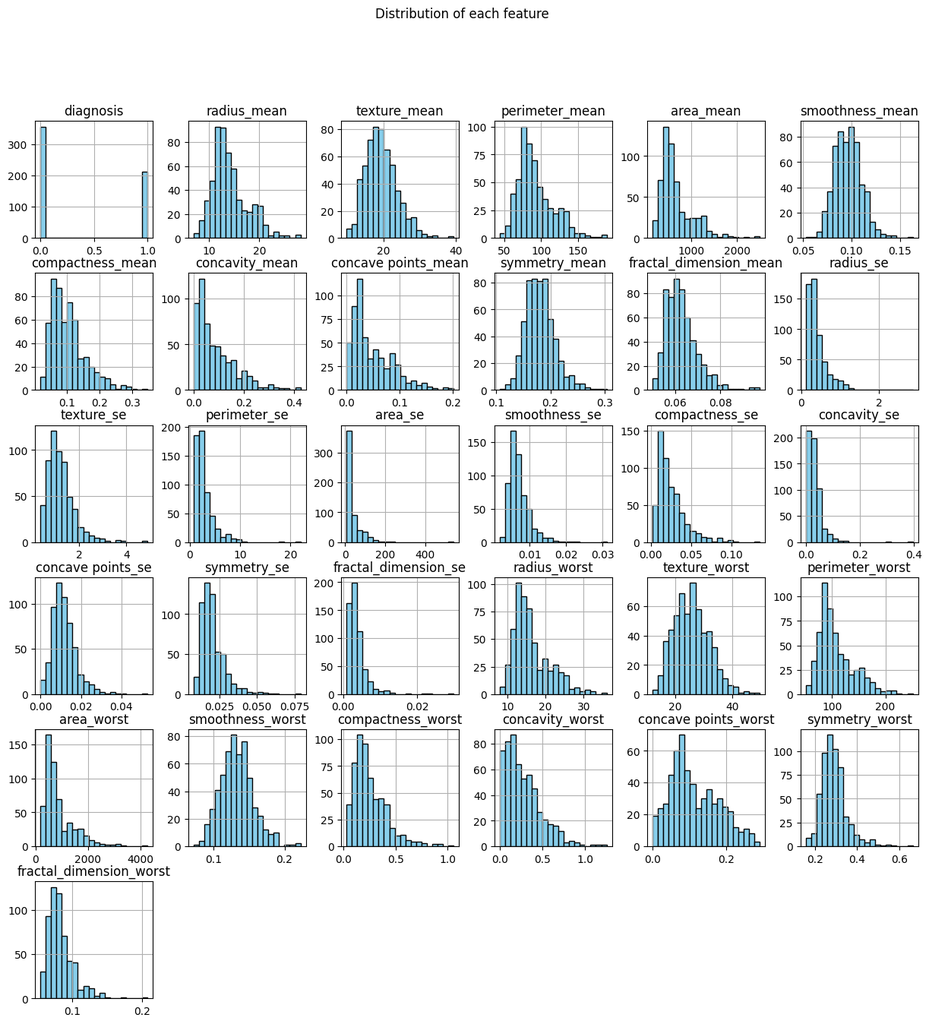

```python
df.hist(bins=20, figsize=(15, 15), color='skyblue', edgecolor='black')
plt.suptitle('Distribution of each feature')
plt.show()
```

##### Outliers Detection

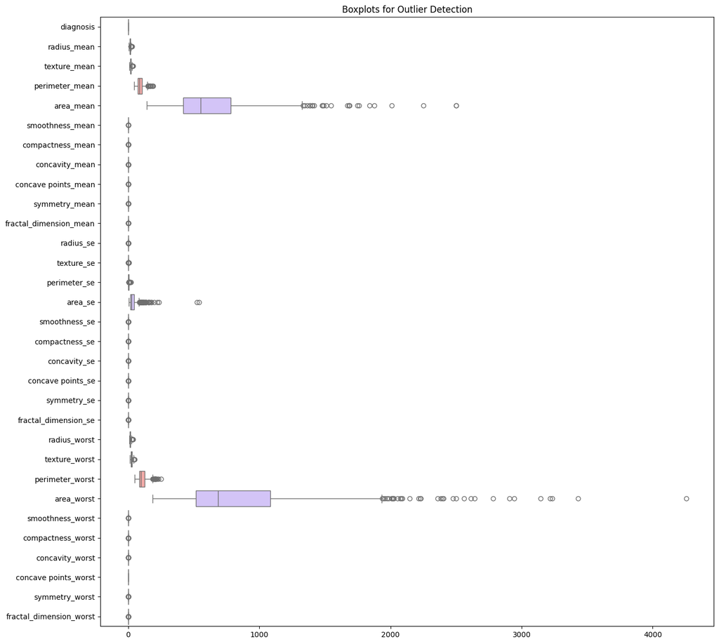

```python
plt.figure(figsize=(15, 15))
sns.boxplot(data=df, orient="h", palette="pastel")
plt.title("Boxplots for Outlier Detection")
plt.show()
```

#### Correlation matrix

We will now do a correlation matrix to find the most relevent variables to predict benign or malign. Focusing on diagnosis, correlations near 1 mean that the higher the value of the parameter, the more likely it is associated with malign. On the contrary, if it is near -1 it means that the higher the value of the parameter, the more likely it is associated with benign. Near 0 means that the parameter and diagnosis are most likely independant from each other.

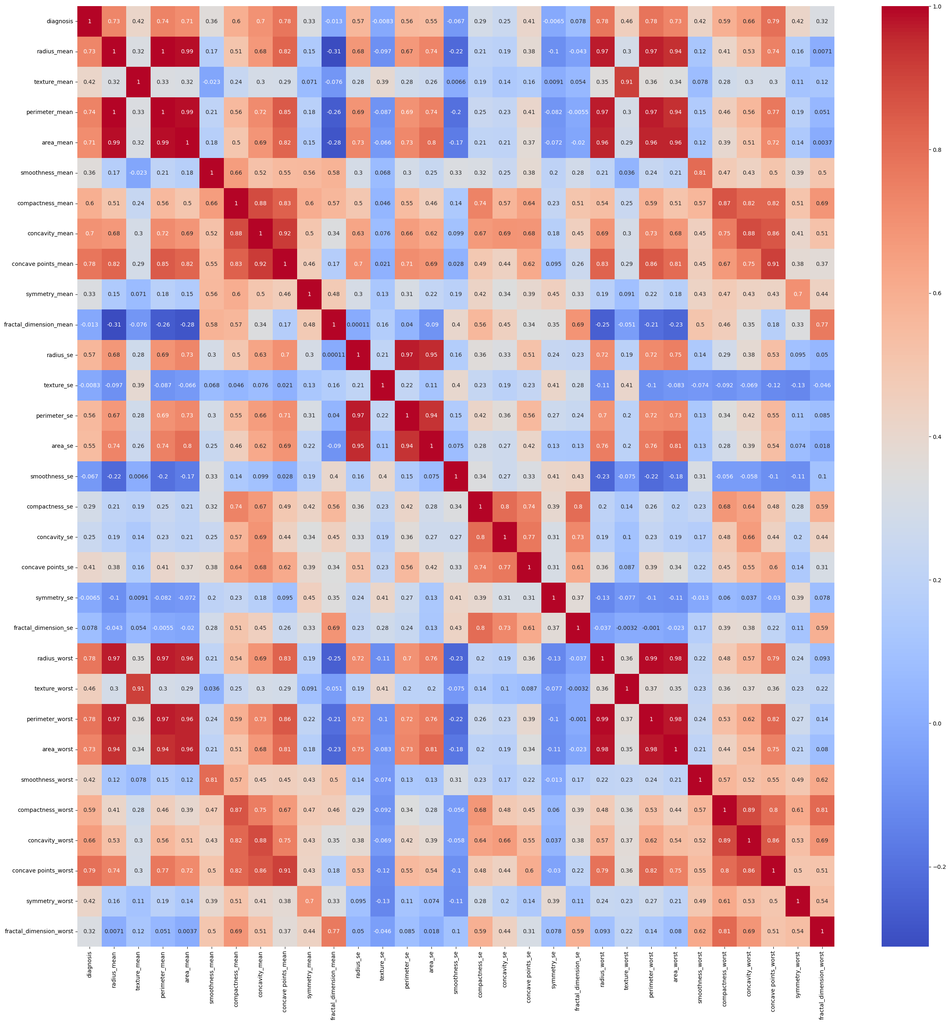

```python
corr_matrix = df.corr()

plt.figure(figsize=(30,30))
sns.heatmap(corr_matrix, annot=True, cmap='coolwarm')
plt.show()
```

We delete the lines that have a too big correlation factor, because they have no additionnal value for our analysis.

```python
df = df.drop(columns=['perimeter_worst', 'perimeter_worst'], axis=1)
df = df.drop(columns=['area_worst', 'area_worst'], axis=1)
df = df.drop(columns=['perimeter_mean', 'perimeter_mean'], axis=1)
df = df.drop(columns=['area_mean', 'area_mean'], axis=1)
df = df.drop(columns=['perimeter_se', 'perimeter_se'], axis=1)
df = df.drop(columns=['area_se', 'area_se'], axis=1)
df = df.drop(columns=['radius_worst', 'radius_worst'], axis=1)
```

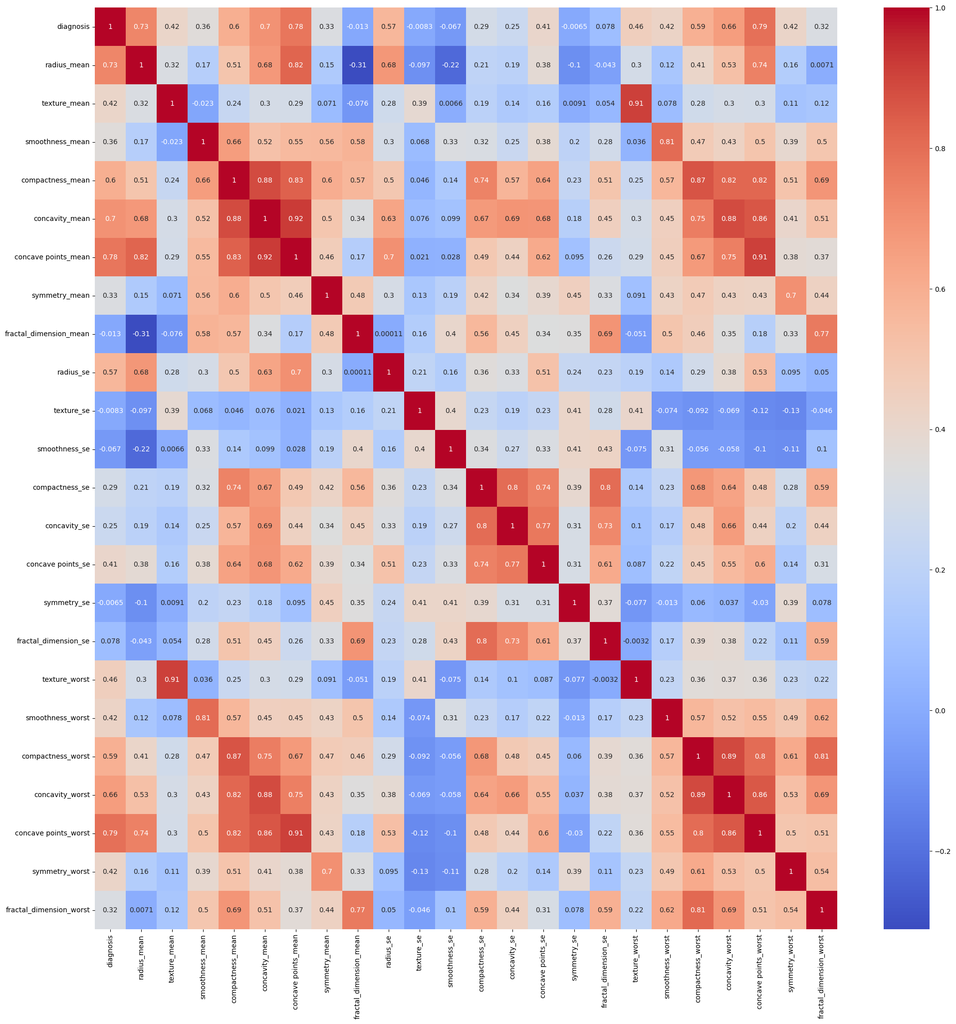

```python
corr_matrix = df.corr()
plt.figure(figsize=(24,24))
sns.heatmap(corr_matrix, annot=True, cmap='coolwarm')
plt.show()
```

### Predictions

#### Preprocessing

##### Standardization and Split

```python
# Standardize the feature data
features = df.drop('diagnosis', axis=1)
scaler = StandardScaler()
features_scaled = scaler.fit_transform(features)

# Spliting features and target
X = features_scaled
y = df['diagnosis']
```

##### PCA

We want to find the number of component with explained variance at 95%

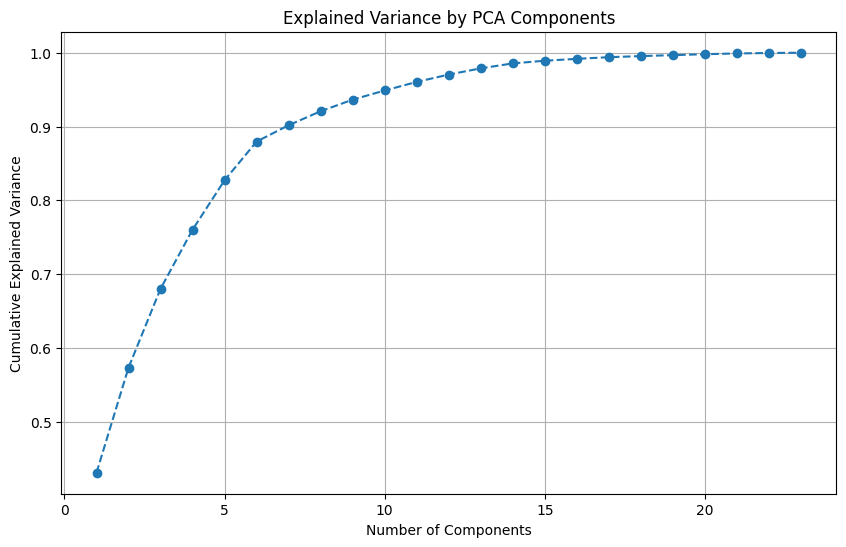

```python
# Perform PCA
pca = PCA()
X_pca = pca.fit_transform(X)

# Plot the explained variance ratio
plt.figure(figsize=(10, 6))
plt.plot(range(1, len(pca.explained_variance_ratio_) + 1), pca.explained_variance_ratio_.cumsum(), marker='o', linestyle='--')
plt.xlabel('Number of Components')
plt.ylabel('Cumulative Explained Variance')
plt.title('Explained Variance by PCA Components')
plt.grid()
plt.show()
```

```python
# Applying PCA
pca_10 = PCA(n_components=10)  # Adjust components as needed
X_pca_10 = pca_10.fit_transform(X)
```

#### Model Predictions

```python
# Create a function so we can use it with and without PCA later on
def models_pred(X_chosen):
    """
    Fonction for prediction with Logistic Regression, SVM, Random Forest and KNN.
    Print the complete raport of the prediction along with the cross-validation for each model
    """
    X_train, X_test, y_train, y_test = train_test_split(X_chosen, y, test_size=0.2, random_state=42)

    models = {
        "Logistic Regression": LogisticRegression(random_state=42),
        "Support Vector Machine (SVM)": SVC(probability=True, random_state=42),
        "Random Forest Classifier": RandomForestClassifier(random_state=42),
        "K-Nearest Neighbors (KNN)": KNeighborsClassifier(n_neighbors=5)
    }

    # For Cross-validation
    cv = StratifiedKFold(n_splits=5, shuffle=True, random_state=42)  # 5-fold cross-validation

    # Train and evaluate each model
    for model_name, model in models.items():
        print(f"\n===== {model_name} =====")

        model.fit(X_train, y_train)

        y_pred = model.predict(X_test)

        accuracy = accuracy_score(y_test, y_pred)
        confusion = confusion_matrix(y_test, y_pred)
        report = classification_report(y_test, y_pred)

        # Cross-validation
        scores = cross_val_score(model, X_chosen, y, cv=cv, scoring='accuracy')
        avg_accuracy = scores.mean()
        std_accuracy = scores.std()

        print("Accuracy:", accuracy)
        print("Confusion Matrix:\n", confusion)
        print("Classification Report:\n", report)
        print("Cross-Validation Accuracy: ", avg_accuracy, " ± ", std_accuracy)
```

##### Without PCA

```python
X
```

```
array([[ 1.09706398, -2.07333501,  1.56846633, ...,  2.29607613,
         2.75062224,  1.93701461],
       [ 1.82982061, -0.35363241, -0.82696245, ...,  1.0870843 ,
        -0.24388967,  0.28118999],
       [ 1.57988811,  0.45618695,  0.94221044, ...,  1.95500035,
         1.152255  ,  0.20139121],
       ...,
       [ 0.70228425,  2.0455738 , -0.84048388, ...,  0.41406869,
        -1.10454895, -0.31840916],
       [ 1.83834103,  2.33645719,  1.52576706, ...,  2.28998549,
         1.91908301,  2.21963528],
       [-1.80840125,  1.22179204, -3.11208479, ..., -1.74506282,
        -0.04813821, -0.75120669]])
```

```python
models_pred(X)
```

```
===== Logistic Regression =====
Accuracy: 0.9649122807017544
Confusion Matrix:
 [[69  2]
 [ 2 41]]
Classification Report:
               precision    recall  f1-score   support

           0       0.97      0.97      0.97        71
           1       0.95      0.95      0.95        43

    accuracy                           0.96       114
   macro avg       0.96      0.96      0.96       114
weighted avg       0.96      0.96      0.96       114

Cross-Validation Accuracy:  0.9736686849868033  ±  0.016627222216787987

===== Support Vector Machine (SVM) =====
Accuracy: 0.956140350877193
Confusion Matrix:
 [[69  2]
 [ 3 40]]
Classification Report:
               precision    recall  f1-score   support

           0       0.96      0.97      0.97        71
           1       0.95      0.93      0.94        43

    accuracy                           0.96       114
   macro avg       0.96      0.95      0.95       114
weighted avg       0.96      0.96      0.96       114

Cross-Validation Accuracy:  0.9736531594472908  ±  0.011071310015572391

===== Random Forest Classifier =====
Accuracy: 0.956140350877193
Confusion Matrix:
 [[70  1]
 [ 4 39]]
Classification Report:
```

[output cut: 12 more lines]

```
Accuracy: 0.9473684210526315
Confusion Matrix:
 [[68  3]
 [ 3 40]]
Classification Report:
               precision    recall  f1-score   support

           0       0.96      0.96      0.96        71
           1       0.93      0.93      0.93        43

    accuracy                           0.95       114
   macro avg       0.94      0.94      0.94       114
weighted avg       0.95      0.95      0.95       114

Cross-Validation Accuracy:  0.9560627231796305  ±  0.011096797231316935
```

##### With PCA (10 components)

```python
X_pca_10
```

```
array([[ 7.86236766e+00, -3.24264006e-01, -2.66529321e+00, ...,
         7.15853687e-01, -6.21433194e-01,  5.41418539e-01],
       [-3.25661873e-01,  2.14882532e+00, -8.30731503e-02, ...,
         2.53299507e-01,  6.76757967e-01, -4.56420056e-03],
       [ 4.09945665e+00,  1.92054750e+00, -1.16377970e-01, ...,
         1.17973702e-01,  3.73864657e-01, -6.26579061e-01],
       ...,
       [ 2.05173723e-01,  2.00528635e+00,  1.93570731e+00, ...,
         1.80785980e-01,  6.38061023e-01, -5.56633301e-01],
       [ 9.44492572e+00,  2.05174016e+00, -3.41681174e-01, ...,
         2.37548966e-01, -2.77163674e-01, -3.25152833e-01],
       [-4.66979607e+00, -3.01649705e-01,  1.57019632e+00, ...,
         1.49792784e+00,  4.52724643e-01,  5.94481405e-01]])
```

```python
models_pred(X_pca_10)
```

```
===== Logistic Regression =====
Accuracy: 0.9736842105263158
Confusion Matrix:
 [[69  2]
 [ 1 42]]
Classification Report:
               precision    recall  f1-score   support

           0       0.99      0.97      0.98        71
           1       0.95      0.98      0.97        43

    accuracy                           0.97       114
   macro avg       0.97      0.97      0.97       114
weighted avg       0.97      0.97      0.97       114

Cross-Validation Accuracy:  0.9718832479428661  ±  0.011630629209317934

===== Support Vector Machine (SVM) =====
Accuracy: 0.9385964912280702
Confusion Matrix:
 [[68  3]
 [ 4 39]]
Classification Report:
               precision    recall  f1-score   support

           0       0.94      0.96      0.95        71
           1       0.93      0.91      0.92        43

    accuracy                           0.94       114
   macro avg       0.94      0.93      0.93       114
weighted avg       0.94      0.94      0.94       114

Cross-Validation Accuracy:  0.9736531594472908  ±  0.014659809305627056

===== Random Forest Classifier =====
Accuracy: 0.9298245614035088
Confusion Matrix:
 [[68  3]
 [ 5 38]]
Classification Report:
```

[output cut: 12 more lines]

```
Accuracy: 0.956140350877193
Confusion Matrix:
 [[68  3]
 [ 2 41]]
Classification Report:
               precision    recall  f1-score   support

           0       0.97      0.96      0.96        71
           1       0.93      0.95      0.94        43

    accuracy                           0.96       114
   macro avg       0.95      0.96      0.95       114
weighted avg       0.96      0.96      0.96       114

Cross-Validation Accuracy:  0.9525384257102933  ±  0.011941410960649008
```

#### Analysis and conclusion of Step 1

We can see that all model performed quite well. But there still are some differences.  
We can make a first choice of models and explore our next possibilities (without PCA):

- KNN did a bit more of missclassification than the others
- RF slightly underperform for malign class with a precision of .97 while a recall at .91
- LR and SVM results are similar with the best F1-scores for both classes while having also minimal overfitting but LR is slightly more effective.

What we will try in Step 2:

- Hyperparameters tuning for LR
- Boosting method with Gradient Boosting
- Stacking method with SVM and RF as base models and LR as meta model

## Stage 2

```python
from sklearn.model_selection import GridSearchCV, ParameterGrid

from sklearn.ensemble import GradientBoostingClassifier

from sklearn.ensemble import StackingClassifier
```

```python
def exec_model(X_chosen, model, model_name):
    """
    Function for exectuting and displaying the results of target model.
    """

    X_train, X_test, y_train, y_test = train_test_split(X_chosen, y, test_size=0.2, random_state=42)

    model.fit(X_train, y_train)

    y_pred = model.predict(X_test)

    accuracy = accuracy_score(y_test, y_pred)
    confusion = confusion_matrix(y_test, y_pred)
    report = classification_report(y_test, y_pred)

    # Cross-validation
    cv = StratifiedKFold(n_splits=5, shuffle=True, random_state=42)
    scores = cross_val_score(model, X_chosen, y, cv=cv, scoring='accuracy')
    avg_accuracy = scores.mean()
    std_accuracy = scores.std()

    print(f"\n===== {model_name} =====")

    print("Accuracy:", accuracy)
    print("Confusion Matrix:\n", confusion)
    print("Classification Report:\n", report)
    print("Cross-Validation Accuracy: ", avg_accuracy, " ± ", std_accuracy)
```

#### Hyperparameter tuning for Logistic Regression

```python
def hyper_tuning_lr(X_chosen, y):
    """
    Function for finding the best parameters for LR.
    """
    params = {
        'C': [0.01, 0.1, 1, 10, 100],
        'penalty': ['l1', 'l2'],
        'solver': ['liblinear', 'lbfgs'],
    }

    # We have to remove the possibility to try penalty l1 with solver lbfgs since it doesn't support it.
    valid_params = [
        param for param in ParameterGrid(params)
        if not (param['solver'] == 'lbfgs' and param['penalty'] == 'l1')
    ]

    param_grid = [{key: [value] for key, value in params.items()} for params in valid_params]

    grid = GridSearchCV(
        LogisticRegression(random_state=42, max_iter=1000),
        param_grid=param_grid,
        cv=5,
        scoring='accuracy',
        verbose=1,
    )
    grid.fit(X_chosen, y)
    return grid.best_params_, np.float64(grid.best_score_)
```

```python
best_params, best_score = hyper_tuning_lr(X, y)
best_params_pca, best_score_pca = hyper_tuning_lr(X_pca_10, y)

print(f"Best Parameters LR: {best_params}")

print(f"Best Parameters LR PCA: {best_params_pca}")
```

```
Fitting 5 folds for each of 15 candidates, totalling 75 fits
Fitting 5 folds for each of 15 candidates, totalling 75 fits
Best Parameters LR: {'C': 1, 'penalty': 'l2', 'solver': 'liblinear'}
Best Parameters LR PCA: {'C': 1, 'penalty': 'l2', 'solver': 'liblinear'}
```

```python
best_lr = LogisticRegression(
    C=best_params['C'],
    penalty=best_params['penalty'],
    solver=best_params['solver'],
    random_state=42,
    max_iter=1000
)

best_lr_pca = LogisticRegression(
    C=best_params_pca['C'],
    penalty=best_params_pca['penalty'],
    solver=best_params_pca['solver'],
    random_state=42,
    max_iter=1000
)

exec_model(X, best_lr, model_name="Tuned LR")
exec_model(X_pca_10, best_lr_pca, model_name="Tuned LR PCA")
```

```
===== Tuned LR =====
Accuracy: 0.9736842105263158
Confusion Matrix:
 [[69  2]
 [ 1 42]]
Classification Report:
               precision    recall  f1-score   support

           0       0.99      0.97      0.98        71
           1       0.95      0.98      0.97        43

    accuracy                           0.97       114
   macro avg       0.97      0.97      0.97       114
weighted avg       0.97      0.97      0.97       114

Cross-Validation Accuracy:  0.9754230709517155  ±  0.014017644997030473

===== Tuned LR PCA =====
Accuracy: 0.9736842105263158
Confusion Matrix:
 [[69  2]
 [ 1 42]]
Classification Report:
               precision    recall  f1-score   support

           0       0.99      0.97      0.98        71
           1       0.95      0.98      0.97        43

    accuracy                           0.97       114
   macro avg       0.97      0.97      0.97       114
weighted avg       0.97      0.97      0.97       114

Cross-Validation Accuracy:  0.9736531594472908  ±  0.012383561951220888
```

Comparison of the 4 LR models we end up with:

Without tuning :

No PCA : acc : 0.9649122807017544 cv : 0.9736686849868033 ± 0.016627222216787987

PCA : acc : 0.9736842105263158 cv : 0.9718832479428661 ± 0.011630629209317934

With best tuning :

No PCA : acc : 0.9736842105263158 cv : 0.9754230709517155 ± 0.014017644997030473

PCA : acc : 0.9736842105263158 cv : 0.9736531594472908 ± 0.012383561951220888

Our goal is to keep the model with the best accuracy with the best cross-validation possible.

Thus, our best LR model is the one with the best tuning hyperparameters (R:1, penalty:l2, solver:liblinear) without PCA because it has the best accuracy (equals to both PCA models) and a cv slightly better which means it's less prone to overfitting and might generalize better than others.

#### Gradient Boosting

```python
GB_model = GradientBoostingClassifier(random_state=42)

exec_model(X, GB_model, model_name="Gradient Boosting")
exec_model(X_pca_10, GB_model, model_name="Gradient Boosting PCA")
```

```
===== Gradient Boosting =====
Accuracy: 0.956140350877193
Confusion Matrix:
 [[69  2]
 [ 3 40]]
Classification Report:
               precision    recall  f1-score   support

           0       0.96      0.97      0.97        71
           1       0.95      0.93      0.94        43

    accuracy                           0.96       114
   macro avg       0.96      0.95      0.95       114
weighted avg       0.96      0.96      0.96       114

Cross-Validation Accuracy:  0.9561092997981679  ±  0.013529294002046128

===== Gradient Boosting PCA =====
Accuracy: 0.9122807017543859
Confusion Matrix:
 [[67  4]
 [ 6 37]]
Classification Report:
               precision    recall  f1-score   support

           0       0.92      0.94      0.93        71
           1       0.90      0.86      0.88        43

    accuracy                           0.91       114
   macro avg       0.91      0.90      0.91       114
weighted avg       0.91      0.91      0.91       114

Cross-Validation Accuracy:  0.9473218444340941  ±  0.019154678024327708
```

First, as we could predict, GB performs worse with PCA due to its decison tree nature : it does not need feature transformation.

Second, we see that our GB without PCA performs good but not as well as our best LR model. This is probably because our dataset is not very complex and GB might have overfit a bit more when comparing its cv with LR's.

#### Stacking

```python
base_models = [
    ('svm', SVC(probability=True, random_state=42)),
    ('rf', RandomForestClassifier(random_state=42))
]
meta_model = LogisticRegression(random_state=42)
stacking_model = StackingClassifier(estimators=base_models, final_estimator=meta_model, cv=5)

exec_model(X, stacking_model, model_name="Stacking Model")
exec_model(X_pca_10, stacking_model, model_name="Stacking Model PCA")
```

```
===== Stacking Model =====
Accuracy: 0.956140350877193
Confusion Matrix:
 [[68  3]
 [ 2 41]]
Classification Report:
               precision    recall  f1-score   support

           0       0.97      0.96      0.96        71
           1       0.93      0.95      0.94        43

    accuracy                           0.96       114
   macro avg       0.95      0.96      0.95       114
weighted avg       0.96      0.96      0.96       114

Cross-Validation Accuracy:  0.9754230709517155  ±  0.016995013229745056

===== Stacking Model PCA =====
Accuracy: 0.956140350877193
Confusion Matrix:
 [[68  3]
 [ 2 41]]
Classification Report:
               precision    recall  f1-score   support

           0       0.97      0.96      0.96        71
           1       0.93      0.95      0.94        43

    accuracy                           0.96       114
   macro avg       0.95      0.96      0.95       114
weighted avg       0.96      0.96      0.96       114

Cross-Validation Accuracy:  0.9718987734823784  ±  0.012866823069459557
```

#### Voting Classifier

```python
from sklearn.ensemble import VotingClassifier

model1 = LogisticRegression(random_state=42)
model2 = SVC(probability=True, random_state=42)
model3 = RandomForestClassifier(random_state=42)

voting_clf = VotingClassifier(estimators=[('lr', model1), ('svc', model2), ('rf', model3)], voting='hard')

exec_model(X, voting_clf, model_name="Voting Classifier")
exec_model(X_pca_10, voting_clf, model_name="Voting Classifier PCA")
```

```
===== Voting Classifier =====
Accuracy: 0.9736842105263158
Confusion Matrix:
 [[70  1]
 [ 2 41]]
Classification Report:
               precision    recall  f1-score   support

           0       0.97      0.99      0.98        71
           1       0.98      0.95      0.96        43

    accuracy                           0.97       114
   macro avg       0.97      0.97      0.97       114
weighted avg       0.97      0.97      0.97       114

Cross-Validation Accuracy:  0.9771774569166277  ±  0.010505640563589476

===== Voting Classifier PCA =====
Accuracy: 0.956140350877193
Confusion Matrix:
 [[69  2]
 [ 3 40]]
Classification Report:
               precision    recall  f1-score   support

           0       0.96      0.97      0.97        71
           1       0.95      0.93      0.94        43

    accuracy                           0.96       114
   macro avg       0.96      0.95      0.95       114
weighted avg       0.96      0.96      0.96       114

Cross-Validation Accuracy:  0.9771619313771154  ±  0.010510962244929627
```

The Voting Classifier is even more stable than our best LR model since it has a better CV, making it our best model for now.

#### Analysis and Conlusion Stage 2:

The Voting Classifier showed impressive performance, with an accuracy of 97.37% without PCA. This model was more stable than others, such as Gradient Boosting and SVM, which showed varying performance depending on PCA. GB performed worse with PCA due to its decision tree structure, which doesn’t benefit from feature transformation.

Overall, well tuned Logistic Regression without PCA and our Voting Classifier were the most stable and effective models.

What we will do for stage 3:

- Try XGBoost or LightGBM, which are powerful boosting algorithms that might outperform current models, especially in handling complex relationships in the data.
- Search for deep learning implementation if possible

## Stage 3

```python
from tensorflow.keras.utils import to_categorical

from tensorflow.keras.models import Sequential
from tensorflow.keras.layers import Dense, Dropout
from tensorflow.keras.callbacks import EarlyStopping

from imblearn.over_sampling import SMOTE
```

For this Stage 3, we wanted to implement a deep learning model even though our dataset didn't have a lot of rows.

We opted for a MLP architecture which should be well suited for a tabular dataset like our breast cancer dataset.

We found this technique by looking at an article that talks about implementing an hybride approch with CNN and a second dataset with breast cancer images: [Deep Learning For Breast Cancer Anlysis](https://pmc.ncbi.nlm.nih.gov/articles/PMC9818155/)

The network will consist of 2 hidden layers with relu activation functions to capture non-linear relationships, a dropout to regularize and prevent overfitting, as well as a softmax activation function in the output layer to enable binary classification into begnign and malign categories. We will use categorical cross-entropy as the loss function and the adam optimizer to ensure efficient weight updates.

```python
X_train, X_test, y_train, y_test = train_test_split(X, y, test_size=0.2, random_state=42, stratify=y)
```

#### MLP implementation

```python
def build_mlp():
    model = Sequential([
        Dense(64, activation='relu', input_shape=(X_train.shape[1],)),
        Dropout(0.3),
        Dense(32, activation='relu'),
        Dense(2, activation='softmax')  # Binary classification
    ])
    model.compile(optimizer='adam', loss='categorical_crossentropy', metrics=['accuracy'])
    return model

mlp_model = build_mlp()
```

```python
# Compile the model
mlp_model.compile(
    optimizer='adam',
    loss='categorical_crossentropy',
    metrics=['accuracy']
)
```

#### Without SMOTE

```python
# One-hot encode the labels
y_train_encoded = to_categorical(y_train)
y_test_encoded = to_categorical(y_test)

# Train the model with early stopping
early_stop = EarlyStopping(monitor='val_loss', patience=5, restore_best_weights=True)
```

```python
history = mlp_model.fit(
    X_train, y_train_encoded,
    validation_split=0.2,
    epochs=50,
    batch_size=16,
    callbacks=[early_stop],
    verbose=1
)
```

```
23/23 ━━━━━━━━━━━━━━━━━━━━ 2s 16ms/step - accuracy: 0.6630 - loss: 0.6172 - val_accuracy: 0.9341 - val_loss: 0.2750
23/23 ━━━━━━━━━━━━━━━━━━━━ 0s 6ms/step - accuracy: 0.9270 - loss: 0.2671 - val_accuracy: 0.9231 - val_loss: 0.1886
23/23 ━━━━━━━━━━━━━━━━━━━━ 0s 6ms/step - accuracy: 0.9537 - loss: 0.1705 - val_accuracy: 0.9341 - val_loss: 0.1511
23/23 ━━━━━━━━━━━━━━━━━━━━ 0s 6ms/step - accuracy: 0.9364 - loss: 0.1452 - val_accuracy: 0.9451 - val_loss: 0.1330
23/23 ━━━━━━━━━━━━━━━━━━━━ 0s 6ms/step - accuracy: 0.9631 - loss: 0.1193 - val_accuracy: 0.9451 - val_loss: 0.1213
23/23 ━━━━━━━━━━━━━━━━━━━━ 0s 6ms/step - accuracy: 0.9773 - loss: 0.0769 - val_accuracy: 0.9560 - val_loss: 0.1130
23/23 ━━━━━━━━━━━━━━━━━━━━ 0s 6ms/step - accuracy: 0.9697 - loss: 0.0846 - val_accuracy: 0.9560 - val_loss: 0.1064
23/23 ━━━━━━━━━━━━━━━━━━━━ 0s 6ms/step - accuracy: 0.9817 - loss: 0.0670 - val_accuracy: 0.9451 - val_loss: 0.1086
23/23 ━━━━━━━━━━━━━━━━━━━━ 0s 6ms/step - accuracy: 0.9864 - loss: 0.0464 - val_accuracy: 0.9560 - val_loss: 0.1026
23/23 ━━━━━━━━━━━━━━━━━━━━ 0s 6ms/step - accuracy: 0.9804 - loss: 0.0608 - val_accuracy: 0.9560 - val_loss: 0.1003
23/23 ━━━━━━━━━━━━━━━━━━━━ 0s 6ms/step - accuracy: 0.9950 - loss: 0.0420 - val_accuracy: 0.9451 - val_loss: 0.1009
23/23 ━━━━━━━━━━━━━━━━━━━━ 0s 6ms/step - accuracy: 0.9883 - loss: 0.0514 - val_accuracy: 0.9451 - val_loss: 0.1040
23/23 ━━━━━━━━━━━━━━━━━━━━ 0s 6ms/step - accuracy: 0.9929 - loss: 0.0422 - val_accuracy: 0.9451 - val_loss: 0.1044
23/23 ━━━━━━━━━━━━━━━━━━━━ 0s 6ms/step - accuracy: 0.9832 - loss: 0.0442 - val_accuracy: 0.9451 - val_loss: 0.1075
23/23 ━━━━━━━━━━━━━━━━━━━━ 0s 6ms/step - accuracy: 0.9806 - loss: 0.0467 - val_accuracy: 0.9451 - val_loss: 0.1084
```

```python
# Evaluate on the test set
test_loss, test_accuracy = mlp_model.evaluate(X_test, y_test_encoded, verbose=0)

y_pred = np.argmax(mlp_model.predict(X_test), axis=1)
conf_matrix = confusion_matrix(y_test, y_pred)
class_report = classification_report(y_test, y_pred)

print(f"Test Loss: {test_loss:.4f}")
print(f"Test Accuracy: {test_accuracy:.4f}")
print("Confusion Matrix:\n", conf_matrix)
print("Classification Report:\n", class_report)
```

```
4/4 ━━━━━━━━━━━━━━━━━━━━ 0s 21ms/step
Test Loss: 0.0807
Test Accuracy: 0.9825
Confusion Matrix:
 [[72  0]
 [ 2 40]]
Classification Report:
               precision    recall  f1-score   support

           0       0.97      1.00      0.99        72
           1       1.00      0.95      0.98        42

    accuracy                           0.98       114
   macro avg       0.99      0.98      0.98       114
weighted avg       0.98      0.98      0.98       114
```

The MLP model trained without SMOTE performs well but may suffer from class imbalance issues.

The precision and recall for the minority class (malignant) are critical metrics to evaluate.

We will now apply SMOTE to address the class imbalance and analyze its impact on the model's performance.

#### With SMOTE

```python
X_train, X_test, y_train, y_test = train_test_split(X, y, test_size=0.2, random_state=42)
```

```python
# Apply SMOTE
smote = SMOTE(random_state=42)
X_train_smote, y_train_smote = smote.fit_resample(X_train, y_train)
```

```python
y_train_smote_encoded = to_categorical(y_train_smote)
y_test_encoded = to_categorical(y_test)
```

```python
history_smote = mlp_model.fit(
    X_train_smote, y_train_smote_encoded,
    validation_split=0.2,
    epochs=50,
    batch_size=16,
    callbacks=[early_stop],
    verbose=1
)
```

[output not shown]

```python
test_loss_smote, test_accuracy_smote = mlp_model.evaluate(X_test, y_test_encoded, verbose=0)

y_pred_smote = np.argmax(mlp_model.predict(X_test), axis=1)
conf_matrix_smote = confusion_matrix(y_test, y_pred_smote)
class_report_smote = classification_report(y_test, y_pred_smote)

print(f"Test Loss (SMOTE): {test_loss_smote:.4f}")
print(f"Test Accuracy (SMOTE): {test_accuracy_smote:.4f}")
print("Confusion Matrix (SMOTE):\n", conf_matrix_smote)
print("Classification Report (SMOTE):\n", class_report_smote)
```

```
4/4 ━━━━━━━━━━━━━━━━━━━━ 0s 5ms/step
Test Loss (SMOTE): 0.1552
Test Accuracy (SMOTE): 0.9649
Confusion Matrix (SMOTE):
 [[69  2]
 [ 2 41]]
Classification Report (SMOTE):
               precision    recall  f1-score   support

           0       0.97      0.97      0.97        71
           1       0.95      0.95      0.95        43

    accuracy                           0.96       114
   macro avg       0.96      0.96      0.96       114
weighted avg       0.96      0.96      0.96       114
```

Applying SMOTE improves the balance between precision and recall for the minority class.

While precision for malignant cases slightly decreases, the recall remains the same. This indicates a trade-off where the model becomes slightly more inclusive at the cost of additional false positives.

Comparison of Results

| **Metric** | **Without SMOTE** | **With SMOTE** |
| --- | --- | --- |
| **Test Accuracy** | 98.25% | 96.49% |
| **Test Loss** | 0.0807 | 0.1552 |
| **Precision (Malignant)** | 1.00 | 0.95 |
| **Recall (Malignant)** | 0.95 | 0.95 |
| **F1-Score (Malignant)** | 0.98 | 0.95 |
| **False Negatives** | 2 | 2 |
| **False Positives** | 0 | 2 |

In this case, the model without SMOTE achieves better overall performance and may be more suitable for the dataset and task, given the minimal difference in recall and the critical need to avoid false positives and false negatives in medical diagnostics.

In conclusion, the best model we could have trained is the MLP one without SMOTE with an accuracy of 98.25%. It beats our best LR model which was at 97.37%.

Final note: our dataset was not big at all so it is difficult to see the actual difference between the models: maybe on a 1000 rows dataset, the MLP with SMOTE would have less false positives and false negatives than without SMOTE and our fine tuned LR.